# Instrucción 5

Con el objetivo de incrementar la precisión y capacidad de generalización del modelo en la predicción de dígitos, se realizaron diversas mejoras al primer diseño de red neuronal. A continuación, se detallan los principales cambios y sus aportaciones:

1. Normalización de las imágenes

En la nueva versión, los valores de los píxeles se escalan al rango [0, 1] mediante la división entre 255.

Esta normalización reduce la variabilidad numérica entre las entradas y facilita la convergencia del modelo durante el entrenamiento.

2. Adición de una dimensión de canal (reshape)

Se añadió una dimensión adicional a las imágenes ((28, 28, 1)) para adaptarlas al formato esperado por los métodos de aumento de datos (data augmentation).

3. Implementación de Data Augmentation

Se integró un generador de imágenes (ImageDataGenerator) que aplica transformaciones aleatorias como rotaciones, desplazamientos y zoom.

Estas modificaciones incrementan la diversidad del conjunto de entrenamiento, ayudando al modelo a generalizar mejor y a evitar el sobreajuste.

4. Ampliación de la arquitectura de la red neuronal

El modelo mejorado incluye una capa adicional densa de 64 neuronas y el uso de funciones de activación ReLU, lo cual incrementa la capacidad de aprendizaje y la profundidad del modelo, permitiendo capturar relaciones más complejas entre los píxeles y las etiquetas.

5. Incorporación de capas Dropout

Se añadieron dos capas de Dropout con una tasa del 20% (0.2) para desactivar aleatoriamente neuronas durante el entrenamiento.

Esta técnica es fundamental para reducir el riesgo de sobreajuste, ya que evita que el modelo dependa excesivamente de patrones específicos del conjunto de entrenamiento.

6. Cambio en la estrategia de validación

A diferencia del primer modelo, que utilizaba una división fija del 40% del conjunto de entrenamiento, el nuevo código emplea directamente el conjunto de prueba como validación durante el entrenamiento con data augmentation, lo que ofrece una evaluación más realista del desempeño general del modelo.

```
Shape of training images: (60000, 28, 28, 1)
Shape of training labels: (60000,)
Shape of testing images: (10000, 28, 28, 1)
Shape of testing labels: (10000,)
```

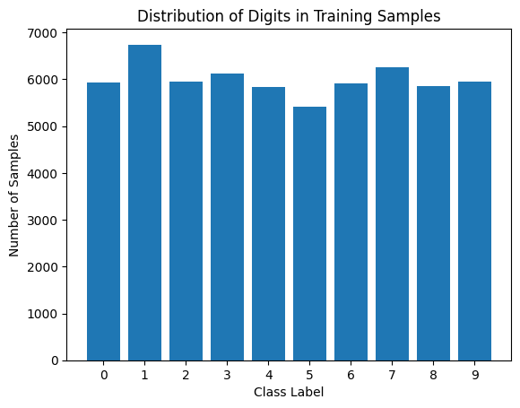

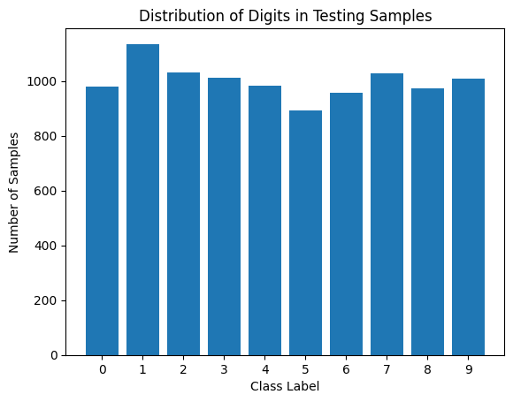

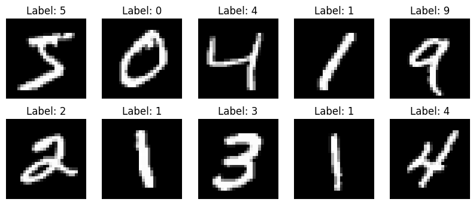

```
Min pixel value in training set: 0.0
Max pixel value in training set: 1.0
```

```
Model: "sequential_3"
```

```
┏━━━━━━━━━━━━━━━━━━━━━━━━━━━━━━━━━┳━━━━━━━━━━━━━━━━━━━━━━━━┳━━━━━━━━━━━━━━━┓
┃ Layer (type)                    ┃ Output Shape           ┃       Param # ┃
┡━━━━━━━━━━━━━━━━━━━━━━━━━━━━━━━━━╇━━━━━━━━━━━━━━━━━━━━━━━━╇━━━━━━━━━━━━━━━┩
│ flatten_3 (Flatten)             │ (None, 784)            │             0 │
├─────────────────────────────────┼────────────────────────┼───────────────┤
│ dense_9 (Dense)                 │ (None, 128)            │       100,480 │
├─────────────────────────────────┼────────────────────────┼───────────────┤
│ dropout_6 (Dropout)             │ (None, 128)            │             0 │
├─────────────────────────────────┼────────────────────────┼───────────────┤
│ dense_10 (Dense)                │ (None, 64)             │         8,256 │
├─────────────────────────────────┼────────────────────────┼───────────────┤
│ dropout_7 (Dropout)             │ (None, 64)             │             0 │
├─────────────────────────────────┼────────────────────────┼───────────────┤
│ dense_11 (Dense)                │ (None, 10)             │           650 │
└─────────────────────────────────┴────────────────────────┴───────────────┘
```

```
 Total params: 109,386 (427.29 KB)
```

```
 Trainable params: 109,386 (427.29 KB)
```

```
 Non-trainable params: 0 (0.00 B)
```

```
1875/1875 ━━━━━━━━━━━━━━━━━━━━ 28s 14ms/step - accuracy: 0.6692 - loss: 1.0118 - val_accuracy: 0.9563 - val_loss: 0.1547
1875/1875 ━━━━━━━━━━━━━━━━━━━━ 24s 13ms/step - accuracy: 0.8852 - loss: 0.3777 - val_accuracy: 0.9606 - val_loss: 0.1238
1875/1875 ━━━━━━━━━━━━━━━━━━━━ 24s 13ms/step - accuracy: 0.9065 - loss: 0.3070 - val_accuracy: 0.9704 - val_loss: 0.0960
1875/1875 ━━━━━━━━━━━━━━━━━━━━ 24s 13ms/step - accuracy: 0.9169 - loss: 0.2699 - val_accuracy: 0.9717 - val_loss: 0.0917
1875/1875 ━━━━━━━━━━━━━━━━━━━━ 24s 13ms/step - accuracy: 0.9233 - loss: 0.2517 - val_accuracy: 0.9699 - val_loss: 0.0892
1875/1875 ━━━━━━━━━━━━━━━━━━━━ 24s 13ms/step - accuracy: 0.9287 - loss: 0.2290 - val_accuracy: 0.9763 - val_loss: 0.0796
1875/1875 ━━━━━━━━━━━━━━━━━━━━ 24s 13ms/step - accuracy: 0.9300 - loss: 0.2329 - val_accuracy: 0.9757 - val_loss: 0.0777
1875/1875 ━━━━━━━━━━━━━━━━━━━━ 24s 13ms/step - accuracy: 0.9319 - loss: 0.2174 - val_accuracy: 0.9768 - val_loss: 0.0733
1875/1875 ━━━━━━━━━━━━━━━━━━━━ 24s 13ms/step - accuracy: 0.9328 - loss: 0.2223 - val_accuracy: 0.9791 - val_loss: 0.0664
1875/1875 ━━━━━━━━━━━━━━━━━━━━ 25s 13ms/step - accuracy: 0.9357 - loss: 0.2166 - val_accuracy: 0.9779 - val_loss: 0.0647
1875/1875 ━━━━━━━━━━━━━━━━━━━━ 23s 13ms/step - accuracy: 0.9386 - loss: 0.2004 - val_accuracy: 0.9803 - val_loss: 0.0638
1875/1875 ━━━━━━━━━━━━━━━━━━━━ 24s 13ms/step - accuracy: 0.9438 - loss: 0.1869 - val_accuracy: 0.9787 - val_loss: 0.0686
1875/1875 ━━━━━━━━━━━━━━━━━━━━ 23s 12ms/step - accuracy: 0.9419 - loss: 0.1913 - val_accuracy: 0.9803 - val_loss: 0.0604
1875/1875 ━━━━━━━━━━━━━━━━━━━━ 24s 13ms/step - accuracy: 0.9425 - loss: 0.1905 - val_accuracy: 0.9816 - val_loss: 0.0588
1875/1875 ━━━━━━━━━━━━━━━━━━━━ 23s 12ms/step - accuracy: 0.9402 - loss: 0.1959 - val_accuracy: 0.9814 - val_loss: 0.0594
1875/1875 ━━━━━━━━━━━━━━━━━━━━ 23s 12ms/step - accuracy: 0.9436 - loss: 0.1837 - val_accuracy: 0.9800 - val_loss: 0.0626
1875/1875 ━━━━━━━━━━━━━━━━━━━━ 23s 12ms/step - accuracy: 0.9433 - loss: 0.1859 - val_accuracy: 0.9814 - val_loss: 0.0574
1875/1875 ━━━━━━━━━━━━━━━━━━━━ 23s 12ms/step - accuracy: 0.9444 - loss: 0.1776 - val_accuracy: 0.9818 - val_loss: 0.0593
1875/1875 ━━━━━━━━━━━━━━━━━━━━ 23s 12ms/step - accuracy: 0.9456 - loss: 0.1802 - val_accuracy: 0.9817 - val_loss: 0.0608
1875/1875 ━━━━━━━━━━━━━━━━━━━━ 23s 12ms/step - accuracy: 0.9466 - loss: 0.1771 - val_accuracy: 0.9810 - val_loss: 0.0606
1875/1875 ━━━━━━━━━━━━━━━━━━━━ 23s 12ms/step - accuracy: 0.9483 - loss: 0.1698 - val_accuracy: 0.9817 - val_loss: 0.0561
1875/1875 ━━━━━━━━━━━━━━━━━━━━ 23s 12ms/step - accuracy: 0.9461 - loss: 0.1747 - val_accuracy: 0.9827 - val_loss: 0.0542
1875/1875 ━━━━━━━━━━━━━━━━━━━━ 23s 12ms/step - accuracy: 0.9477 - loss: 0.1718 - val_accuracy: 0.9816 - val_loss: 0.0574
1875/1875 ━━━━━━━━━━━━━━━━━━━━ 23s 12ms/step - accuracy: 0.9469 - loss: 0.1763 - val_accuracy: 0.9824 - val_loss: 0.0570
1875/1875 ━━━━━━━━━━━━━━━━━━━━ 23s 12ms/step - accuracy: 0.9496 - loss: 0.1680 - val_accuracy: 0.9820 - val_loss: 0.0525
1875/1875 ━━━━━━━━━━━━━━━━━━━━ 23s 12ms/step - accuracy: 0.9498 - loss: 0.1674 - val_accuracy: 0.9841 - val_loss: 0.0511
1875/1875 ━━━━━━━━━━━━━━━━━━━━ 23s 12ms/step - accuracy: 0.9486 - loss: 0.1678 - val_accuracy: 0.9845 - val_loss: 0.0515
1875/1875 ━━━━━━━━━━━━━━━━━━━━ 23s 12ms/step - accuracy: 0.9497 - loss: 0.1672 - val_accuracy: 0.9842 - val_loss: 0.0508
1875/1875 ━━━━━━━━━━━━━━━━━━━━ 23s 12ms/step - accuracy: 0.9502 - loss: 0.1677 - val_accuracy: 0.9844 - val_loss: 0.0496
1875/1875 ━━━━━━━━━━━━━━━━━━━━ 23s 12ms/step - accuracy: 0.9508 - loss: 0.1643 - val_accuracy: 0.9817 - val_loss: 0.0568
1875/1875 ━━━━━━━━━━━━━━━━━━━━ 23s 12ms/step - accuracy: 0.9492 - loss: 0.1645 - val_accuracy: 0.9834 - val_loss: 0.0531
1875/1875 ━━━━━━━━━━━━━━━━━━━━ 23s 12ms/step - accuracy: 0.9516 - loss: 0.1626 - val_accuracy: 0.9857 - val_loss: 0.0489
1875/1875 ━━━━━━━━━━━━━━━━━━━━ 23s 12ms/step - accuracy: 0.9497 - loss: 0.1665 - val_accuracy: 0.9826 - val_loss: 0.0530
1875/1875 ━━━━━━━━━━━━━━━━━━━━ 23s 12ms/step - accuracy: 0.9503 - loss: 0.1633 - val_accuracy: 0.9837 - val_loss: 0.0525
1875/1875 ━━━━━━━━━━━━━━━━━━━━ 22s 12ms/step - accuracy: 0.9510 - loss: 0.1615 - val_accuracy: 0.9855 - val_loss: 0.0455
1875/1875 ━━━━━━━━━━━━━━━━━━━━ 23s 12ms/step - accuracy: 0.9525 - loss: 0.1557 - val_accuracy: 0.9845 - val_loss: 0.0477
1875/1875 ━━━━━━━━━━━━━━━━━━━━ 23s 12ms/step - accuracy: 0.9523 - loss: 0.1582 - val_accuracy: 0.9838 - val_loss: 0.0486
1875/1875 ━━━━━━━━━━━━━━━━━━━━ 23s 12ms/step - accuracy: 0.9519 - loss: 0.1606 - val_accuracy: 0.9842 - val_loss: 0.0502
1875/1875 ━━━━━━━━━━━━━━━━━━━━ 23s 12ms/step - accuracy: 0.9520 - loss: 0.1592 - val_accuracy: 0.9821 - val_loss: 0.0517
1875/1875 ━━━━━━━━━━━━━━━━━━━━ 23s 12ms/step - accuracy: 0.9538 - loss: 0.1469 - val_accuracy: 0.9849 - val_loss: 0.0460
1875/1875 ━━━━━━━━━━━━━━━━━━━━ 23s 12ms/step - accuracy: 0.9528 - loss: 0.1571 - val_accuracy: 0.9849 - val_loss: 0.0471
1875/1875 ━━━━━━━━━━━━━━━━━━━━ 23s 12ms/step - accuracy: 0.9555 - loss: 0.1493 - val_accuracy: 0.9857 - val_loss: 0.0452
```

```python
import matplotlib.pyplot as plt
import cv2 as cv
import numpy as np
import os
import tensorflow as tf
import zipfile
import shutil
from tensorflow.keras.models import Sequential
from tensorflow.keras.layers import Dense, Flatten, Dropout
from tensorflow.keras.datasets import mnist
from tensorflow.keras.callbacks import EarlyStopping
from matplotlib.ticker import MaxNLocator
from tensorflow.keras.models import load_model
from tensorflow.keras.preprocessing.image import ImageDataGenerator
from google.colab import files

(train_images, train_labels), (test_images, test_labels) = mnist.load_data()
train_images = train_images / 255.0
test_images = test_images / 255.0


train_images = np.expand_dims(train_images, axis=-1)
test_images = np.expand_dims(test_images, axis=-1)


print("Shape of training images:", train_images.shape)
print("Shape of training labels:", train_labels.shape)
print("Shape of testing images:", test_images.shape)
print("Shape of testing labels:", test_labels.shape)

unique, counts = np.unique(train_labels, return_counts=True)
plt.bar(unique, counts, tick_label=unique)
plt.title('Distribution of Digits in Training Samples')
plt.xlabel('Class Label')
plt.ylabel('Number of Samples')
plt.show()

unique, counts = np.unique(test_labels, return_counts=True)
plt.bar(unique, counts, tick_label=unique)
plt.title('Distribution of Digits in Testing Samples')
plt.xlabel('Class Label')
plt.ylabel('Number of Samples')
plt.show()

plt.figure(figsize=(10, 4))
for i in range (10):
    plt.subplot(2, 5, i+1)
    plt.imshow(train_images[i], cmap='gray')
    plt.title(f"Label: {train_labels[i]}")
    plt.axis('off')
plt.show()

print(f"Min pixel value in training set: {train_images.min()}")
print(f"Max pixel value in training set: {train_images.max()}")


model = Sequential()
model.add(Flatten(input_shape=(28, 28, 1)))
model.add(Dense(128, activation='relu'))
model.add(Dropout(0.2))
model.add(Dense(64, activation='relu'))
model.add(Dropout(0.2))
model.add(Dense(10, activation='softmax'))

opt = tf.keras.optimizers.Adam(learning_rate=0.001)
model.compile(optimizer=opt, loss='sparse_categorical_crossentropy', metrics=['accuracy'])
model.summary()


datagen = tf.keras.preprocessing.image.ImageDataGenerator(
    rotation_range=10,
    width_shift_range=0.1,
    height_shift_range=0.1,
    zoom_range=0.1
)
datagen.fit(train_images)


early_stop = EarlyStopping(monitor='val_accuracy', patience=10, restore_best_weights=True)
history = model.fit(
    datagen.flow(train_images, train_labels, batch_size=32),
    validation_data=(test_images, test_labels),
    epochs=50,
    callbacks=[early_stop]
)
```

El resto del código se mantiene prácticamente sin cambios, con el objetivo de evaluar de manera consistente el desempeño del nuevo modelo, que fue guardado bajo el nombre "A3.2_2_model.h5".

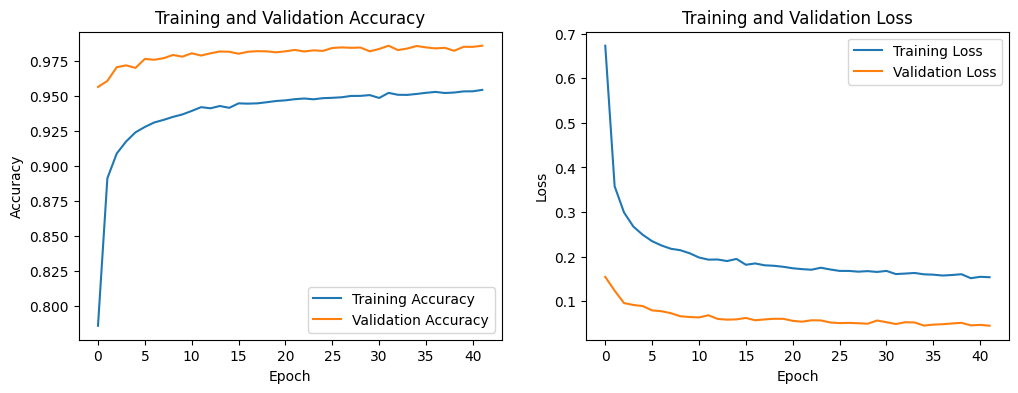

```
Accuracy on training set (best epoch): 0.9521
Accuracy on validation set (best epoch): 0.9857
```

```
WARNING:absl:You are saving your model as an HDF5 file via `model.save()` or `keras.saving.save_model(model)`. This file format is considered legacy. We recommend using instead the native Keras format, e.g. `model.save('my_model.keras')` or `keras.saving.save_model(model, 'my_model.keras')`.
```

```
Accuracy on test set: 0.9857
```

```python
# Visualizar desempeño del modelo

stopped_epoch = early_stop.stopped_epoch
best_epoch = stopped_epoch - early_stop.patience
plt.figure(figsize=(12, 4))

plt.subplot(1, 2, 1)
plt.plot(history.history['accuracy'], label='Training Accuracy')
plt.plot(history.history['val_accuracy'], label='Validation Accuracy')
plt.title('Training and Validation Accuracy')
plt.xlabel('Epoch')
plt.ylabel('Accuracy')
plt.gca().xaxis.set_major_locator(MaxNLocator(integer=True))
plt.legend()

plt.subplot(1, 2, 2)
plt.plot(history.history['loss'], label='Training Loss')
plt.plot(history.history['val_loss'], label='Validation Loss')
plt.title('Training and Validation Loss')
plt.xlabel('Epoch')
plt.ylabel('Loss')
plt.gca().xaxis.set_major_locator(MaxNLocator(integer=True))
plt.legend()
plt.show()

val_accuracy = history.history['val_accuracy'][best_epoch]
train_accuracy = history.history['accuracy'][best_epoch]
print(f"Accuracy on training set (best epoch): {train_accuracy:.4f}")
print(f"Accuracy on validation set (best epoch): {val_accuracy:.4f}")

# Evaluar el modelo en el conjunto de prueba
test_loss, test_accuracy = model.evaluate(test_images, test_labels, verbose=0)
print(f"Accuracy on test set: {test_accuracy:.4f}")
model.save('A3.2_2_model.h5')
```

```
Please, ulpoad zip file with images.
```

Upload widget is only available when the cell has been executed in the current browser session. Please rerun this cell to enable.

```
Saving A3.2_num.zip to A3.2_num (2).zip
```

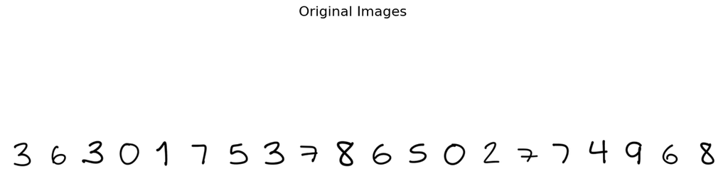

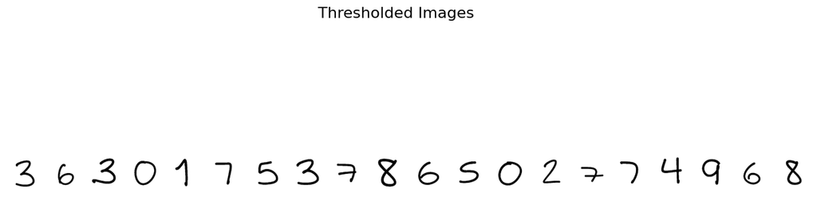

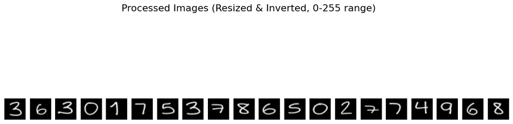

```
WARNING:absl:Compiled the loaded model, but the compiled metrics have yet to be built. `model.compile_metrics` will be empty until you train or evaluate the model.
```

```
Total number of processed images: 50
```

[output not shown]

```
1/2 ━━━━━━━━━━━━━━━━━━━━ 0s 238ms/step
```

[output not shown]

```
2/2 ━━━━━━━━━━━━━━━━━━━━ 0s 213ms/step
Predicted Digits:
611066_3_1.png: 3
611066_6_3.png: 6
611066_3_5.png: 3
611066_0_1.png: 0
611066_1_1.png: 7
611066_7_5.png: 7
611066_5_2.png: 5
611066_3_2.png: 3
611066_7_4.png: 7
611066_8_2.png: 8
611066_6_4.png: 6
611066_5_1.png: 5
611066_0_4.png: 0
611066_2_2.png: 2
611066_7_2.png: 2
611066_7_3.png: 7
611066_4_3.png: 4
611066_9_1.png: 9
611066_6_5.png: 6
611066_8_4.png: 8
611066_8_1.png: 8
611066_6_1.png: 6
611066_9_2.png: 9
611066_5_3.png: 5
611066_8_5.png: 8
611066_0_3.png: 0
611066_2_4.png: 2
611066_5_4.png: 5
611066_3_3.png: 3
611066_9_3.png: 9
611066_5_5.png: 5
611066_2_1.png: 2
611066_4_5.png: 4
611066_2_3.png: 2
611066_0_5.png: 0
611066_9_4.png: 9
611066_1_2.png: 1
611066_2_5.png: 2
611066_4_2.png: 4
611066_9_5.png: 9
611066_8_3.png: 8
611066_4_4.png: 4
611066_6_2.png: 6
611066_1_3.png: 7
611066_1_4.png: 1
611066_3_4.png: 3
611066_4_1.png: 4
611066_7_1.png: 7
611066_0_2.png: 0
611066_1_5.png: 3
Accuracy on uploaded images: 0.9200
Previous accuracy on the test set: 0.9857
```

```python
# Cargar imágenes
print("Please, ulpoad zip file with images.")
uploaded = files.upload()

original_images = []
thresholded_images = []
processed_images = []
image_filenames = []
true_labels = []
temp_dir = "uploaded_images"

if not os.path.exists(temp_dir):
    os.makedirs(temp_dir)

# Revisar archivo
if len(uploaded) != 1:
    print("Please upload only one file.")
elif not list(uploaded.keys())[0].endswith('.zip'):
    print("Please upload a zip file.")
else:
    filename = list(uploaded.keys())[0]
    content = list(uploaded.values())[0]
    file_path = os.path.join(temp_dir, filename)
    with open(file_path, 'wb') as f:
        f.write(content)

    if zipfile.is_zipfile(file_path):
        with zipfile.ZipFile(file_path, 'r') as zip_ref:
            zip_ref.extractall(temp_dir)
        os.remove(file_path)
    else:
        print("The uploaded file is not a valid zip file.")
        shutil.rmtree(temp_dir)
        temp_dir = None

if temp_dir and os.path.exists(temp_dir):
    all_image_paths = []
    for root, _, files_in_folder in os.walk(temp_dir):
        for file_in_folder in files_in_folder:
            all_image_paths.append(os.path.join(root, file_in_folder))

    for img_path in all_image_paths:
        # Leer imagen en grayscale
        img = cv.imread(img_path, cv.IMREAD_GRAYSCALE)

        if img is not None:
            # Threshold
            _, img_thresh = cv.threshold(img, 80, 255, cv.THRESH_BINARY)

            # Resize
            img_resized = cv.resize(img_thresh, (28, 28), interpolation=cv.INTER_AREA)

            # Invert colors
            img_inverted = cv.bitwise_not(img_resized)

            img_processed = img_inverted

            original_images.append(img)
            thresholded_images.append(img_thresh)
            processed_images.append(img_processed)
            image_filenames.append(os.path.basename(img_path))

            # Extraer valor real (formato '611066_true_#_#.png')
            try:
                true_digit_str = os.path.basename(img_path).split('_')[1]
                true_digit = int(true_digit_str)
                true_labels.append(true_digit)
            except (IndexError, ValueError):
                print(f"Warning: Could not extract true label from filename: {os.path.basename(img_path)}")
                true_labels.append(None)

        else:
            print(f"Error loading or processing image: {os.path.basename(img_path)} from {img_path}")

    if original_images:
        plt.figure(figsize=(15, 5))
        plt.suptitle('Original Images', fontsize=16)
        num_images_to_display = min(len(original_images), 20) # Display up to 20 images
        for i in range(num_images_to_display):
            plt.subplot(1, num_images_to_display, i + 1)
            plt.imshow(original_images[i], cmap='gray')
            plt.axis('off')
        plt.show()

    if thresholded_images:
        plt.figure(figsize=(15, 5))
        plt.suptitle('Thresholded Images', fontsize=16)
        num_images_to_display = min(len(thresholded_images), 20) # Display up to 20 images
        for i in range(num_images_to_display):
            plt.subplot(1, num_images_to_display, i + 1)
            plt.imshow(thresholded_images[i], cmap='gray')
            plt.axis('off')
        plt.show()

    if processed_images:
        plt.figure(figsize=(15, 5))
        plt.suptitle('Processed Images (Resized & Inverted, 0-255 range)', fontsize=16)
        num_images_to_display = min(len(processed_images), 20) # Display up to 20 images
        for i in range(num_images_to_display):
            plt.subplot(1, num_images_to_display, i + 1)
            plt.imshow(processed_images[i], cmap='gray')
            plt.axis('off')
        plt.show()

    print(f"Total number of processed images: {len(processed_images)}")


if os.path.exists(temp_dir):
    shutil.rmtree(temp_dir)


if processed_images:
    processed_images = np.array(processed_images)
    try:
        model = load_model('A3.2_2_model.h5')
    except Exception as e:
        print(f"Error loading model: {e}")
        print("Please ensure 'A3.2_2_model.h5' exists and the model was saved correctly.")


    # Hacer predicciones
    if 'model' in locals():
      processed_images_normalized = processed_images / 255.0
      predictions = model.predict(processed_images_normalized)
      predicted_digits = np.argmax(predictions, axis=1)
      print("Predicted Digits:")
      for filename, digit in zip(image_filenames, predicted_digits):
          print(f"{filename}: {digit}")
      if all(label is not None for label in true_labels):
          true_labels_array = np.array(true_labels)
          correct_predictions = np.sum(predicted_digits == true_labels_array)
          accuracy = correct_predictions / len(processed_images)
          print(f"Accuracy on uploaded images: {accuracy:.4f}")
      else:
          print("Accuracy could not be calculated due to missing true labels in some filenames.")
    else:
      print("Model not loaded, cannot make predictions.")
else:
    print("No images were loaded or processed.")
try:
    print(f"Previous accuracy on the test set: {test_accuracy:.4f}")
except NameError:
    print("Previous test accuracy not available. Please run the cell with model training and evaluation.")
```

Como se puede observar en los resultados de predicción sobre la base de datos propia, las mejoras implementadas en el modelo permitieron un incremento significativo en su desempeño, alcanzando un accuracy de 0.92 y predicciones más precisas. Esto confirma que la hipótesis del sobreajuste al conjunto MNIST original era válida, y que pequeños cambios en las imágenes de entrada, así como mejoras en la arquitectura y el preprocesamiento, fueron necesarios para obtener mejores resultados. Cabe destacar que, si bien el modelo entrenado fue significativamente más lento en su ejecución, los resultados obtenidos justifican este incremento en el tiempo de procesamiento debido a la mayor precisión y confiabilidad de las predicciones.

La siguiente parte de la tarea se encontrará en el documento A3.2_3.ipynb